# R Markdown

Developers at RStudio

12 Jan 2021

# R Markdown basics

1. YAML header and setup code chunk
2. Text and formatting
3. Code chunks

## YAML header and initial code chunk

The following YAML header sets up an html document to have the code available but hidden:

`title: "R Markdown"`  
`author: "Developers at RStudio"`  
`date: "9/16/2019"` `output:`  
`html_document:`  
`code_folding: hide`

The setup code chunk often contains libraries.

`{r setup, include = FALSE}`  
`knitr::opts_chunk$set(echo = TRUE, message = FALSE, warning = FALSE)`  
`library(tidyverse)`

## Text and formatting

### Purposes of R Markdown as proposed by Grolemund and Wickham *(Here is an example of an ordered list.)*

1. Communicate with decision makers, who want to focus on the conclusions, not the code behind the analysis.
2. Collaborate with other data scientists (including the future you!), who are interested in both your conclusions, and how you reached them (i.e. the code).
3. Provide an environment suitable for data science, as a modern day lab notebook where you can capture not only what you did, but also what you were thinking.

### Resources

Here are some potential resources when using R Markdown: **(This is an unordered list)**

- [Free R Books](https://bookdown.org/)
- [Website](https://rmarkdown.rstudio.com/)
- [Cheatsheet](https://github.com/rstudio/cheatsheets/raw/master/rmarkdown-2.0.pdf)
- [Reference](https://www.rstudio.com/wp-content/uploads/2015/03/rmarkdown-reference.pdf)

### Consider the following heading levels

# 1st Level Header

## 2nd Level Header

### 3rd Level Header

#### 4rd Level Header

##### 5rd Level Header

###### 6rd Level Header

### Links and images

http://govfinance.byu.edu/govfinance/classes/dataScience/syllabus/dataScienceSyllabus.html

[Class Web Site](http://govfinance.byu.edu/govfinance/classes/dataScience/syllabus/dataScienceSyllabus.html)

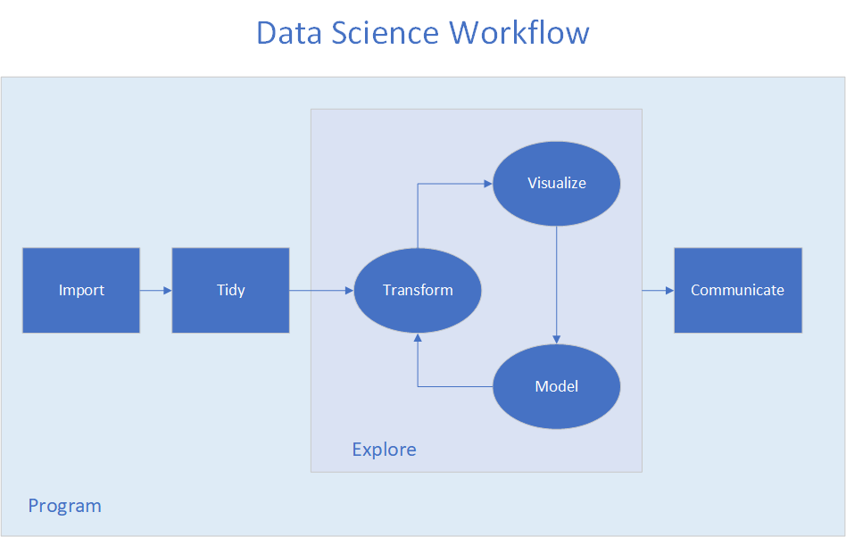

Outline for Our Class

### Equations

#### Inline

The sum of the observations divided by the sample size gives the mean: $\frac{1}{n}\sum\limits_{i = 1}^n {{X_i}}$

#### Display mean formula

$$\frac{1}{n}\sum\limits_{i = 1}^n {{X_i}}$$

### Tables using R Markdown

| First Header | Second Header |
| --- | --- |
| Content Cell | Content Cell |
| Content Cell | Content Cell |

## Code Chunks

### Inline

The number of rows in the mtcars tibble is: 32.

### Display

Scatterplot of highway miles per gallon on engine displacement  
Built-in mpg R data set

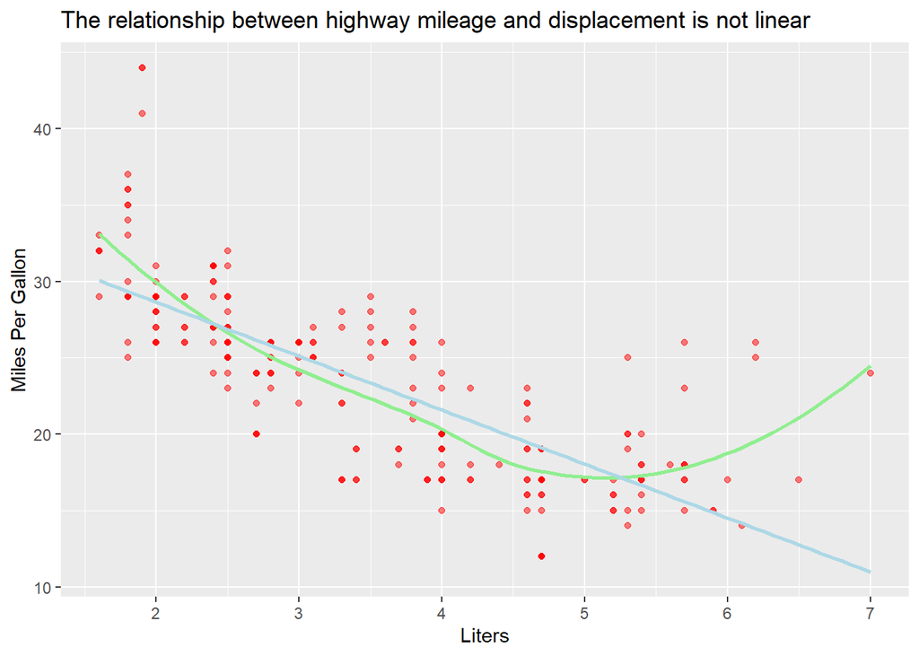

```r
  ggplot(data = mpg, mapping = aes(x = displ, y = hwy)) +
    geom_point(color = "red", alpha = 0.5) +
    geom_smooth(method = "loess", color = "lightgreen", se = FALSE) +
    geom_smooth(method = "lm", color = "lightblue", se = FALSE) +
    labs(
      title = "The relationship between highway mileage and displacement is not linear",
      x = "Liters",
      y = "Miles Per Gallon"
    )
```

Because of the nonlinear pattern, transformations such as those we will cover in Chapter 5 will be appropriate and desirable.

### Tables using R code

```r
head(mtcars, 5)
```

```
##                    mpg cyl disp  hp drat    wt  qsec vs am gear carb
## Mazda RX4         21.0   6  160 110 3.90 2.620 16.46  0  1    4    4
## Mazda RX4 Wag     21.0   6  160 110 3.90 2.875 17.02  0  1    4    4
## Datsun 710        22.8   4  108  93 3.85 2.320 18.61  1  1    4    1
## Hornet 4 Drive    21.4   6  258 110 3.08 3.215 19.44  1  0    3    1
## Hornet Sportabout 18.7   8  360 175 3.15 3.440 17.02  0  0    3    2
```

```r
knitr::kable(
  mtcars[1:5, ],
  caption = "A knitr kable."
)
```

A knitr kable.

|  | mpg | cyl | disp | hp | drat | wt | qsec | vs | am | gear | carb |
| --- | --- | --- | --- | --- | --- | --- | --- | --- | --- | --- | --- |
| Mazda RX4 | 21.0 | 6 | 160 | 110 | 3.90 | 2.620 | 16.46 | 0 | 1 | 4 | 4 |
| Mazda RX4 Wag | 21.0 | 6 | 160 | 110 | 3.90 | 2.875 | 17.02 | 0 | 1 | 4 | 4 |
| Datsun 710 | 22.8 | 4 | 108 | 93 | 3.85 | 2.320 | 18.61 | 1 | 1 | 4 | 1 |
| Hornet 4 Drive | 21.4 | 6 | 258 | 110 | 3.08 | 3.215 | 19.44 | 1 | 0 | 3 | 1 |
| Hornet Sportabout | 18.7 | 8 | 360 | 175 | 3.15 | 3.440 | 17.02 | 0 | 0 | 3 | 2 |